# STA403-1 第三次作业

金科 201756010

### 第五周任务：P182 第8题

通过模拟数据集学习最有自己选择法

（a）使用`rnorm()`生成预测变量$X$和噪声向量$\varepsilon$。

```r
set.seed(1)
x <- rnorm(100)
noise <- rnorm(100)
```

（b）依据以下模型产生长度为$n=100$的响应变量$Y$
$$Y = \beta_0 + \beta_1X + \beta_2X^2 + \beta_3X^3 + \varepsilon$$
其中，$\beta_0=9$、$\beta_1=2$、$\beta_2=5$和$\beta_3=13$是自己选的常数

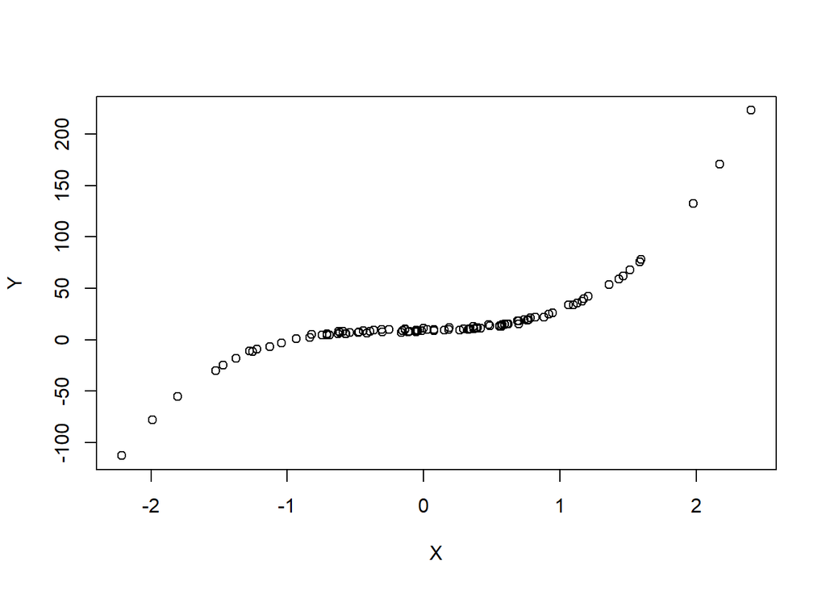

```r
y <- 9 + 2 * x + 5 * x^2 + 13 * x^3 + noise
plot(x, y, xlab = "X", ylab = "Y")
```

（c）使用最优子集选择法，从包含$X$、$X^2$到$X^{10}$的模型中根据$C_p$、BIC和调整R方选出最优……

```r
library(leaps)
library(ggplot2)
```

```r
# 数据准备
data <- data.frame(poly(x, 10, raw = T), y)

# 提取信息绘图
plotf <- function(result) {
  rstBest <- summary(result)
  pBestBIC <- ggplot(data.frame(M = 1:10, BIC = rstBest$bic),
                     aes(x = M, y = BIC)) +
    geom_line() + geom_point() +
    labs(x = NULL, y = NULL, title = "BIC") +
    geom_point(aes(which.min(rstBest$bic), min(rstBest$bic)),
               col="red", size=3)

  pBestAdjR <- ggplot(data.frame(M = 1:10, AdjR2 = rstBest$adjr2),
                      aes(x = M, y = AdjR2)) +
    geom_line() + geom_point() +
    labs(x = NULL, y = NULL, title = "Adj R2") +
    geom_point(aes(which.max(rstBest$adjr2), max(rstBest$adjr2)),
               col="red", size=3)

  pBestCp <- ggplot(data.frame(M = 1:10, Cp = rstBest$cp),
                    aes(x = M, y = Cp)) +
    geom_line()+ geom_point() +
    labs(x = NULL, y = NULL, title = "Cp") +
    geom_point(aes(which.min(rstBest$cp), min(rstBest$cp)),
               col = "red", size = 3)

  cowplot::plot_grid(pBestCp, pBestBIC, pBestAdjR, ncol = 3)
}
```

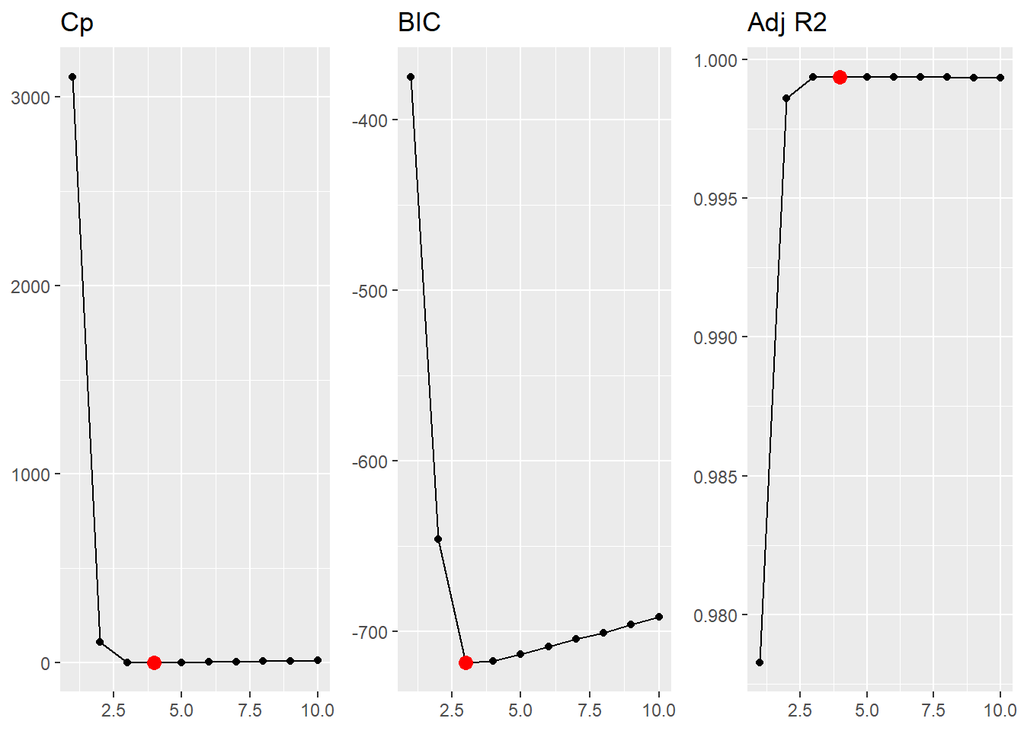

```r
# 最优子集选择法
result_sub <- regsubsets(y ~ ., data = data, nvmax = 10)
plotf(result_sub)
```

如上图所示，综合三项评价指标，可以认为当加入的预测变量数量为4时模型最优，并计算此时各系数的估计值

```r
coef(result_sub, 4)
```

```
## (Intercept)          X1          X2          X3          X5
##  9.07200775  2.38745596  4.84575641 12.55797426  0.08072292
```

（d）使用向前逐步选择法和向后逐步选择法重复（c）中步骤，比较答案

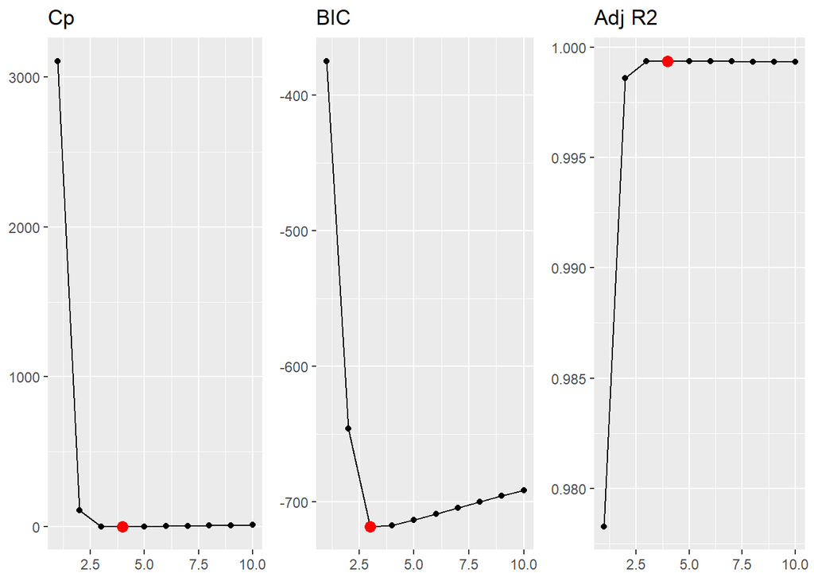

```r
# 向前逐步选择法
result_fwd <- regsubsets(y ~ ., data = data, nvmax = 10, method = "forward")
plotf(result_fwd)
```

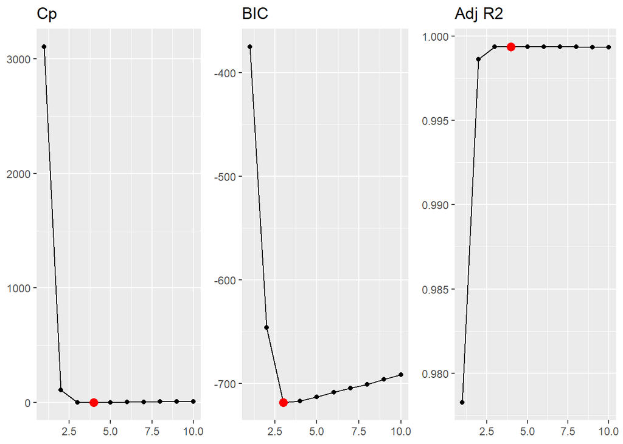

```r
# 向后逐步选择法
result_bwd <- regsubsets(y ~ ., data = data, nvmax = 10, method = "backward")
plotf(result_bwd)
```

```r
coef(result_fwd, 4)
```

```
## (Intercept)          X1          X2          X3          X5
##  9.07200775  2.38745596  4.84575641 12.55797426  0.08072292
```

```r
coef(result_bwd, 4)
```

```
##  (Intercept)           X1           X2           X3           X9
##  9.079236362  2.231905828  4.833494180 12.819555807  0.001290827
```

向前逐步选择法与最优子集选择法的结果一致，向后逐步选择法将$X^5$项替换为了$X^9$，但是两者的系数均很小，可以认为对模型的影响微乎其微；其他参数与原模型系数非常接近。

（e）使用lasso拟合数据，使用交叉验证选择参数$\lambda$的值

```r
library(glmnet)
```

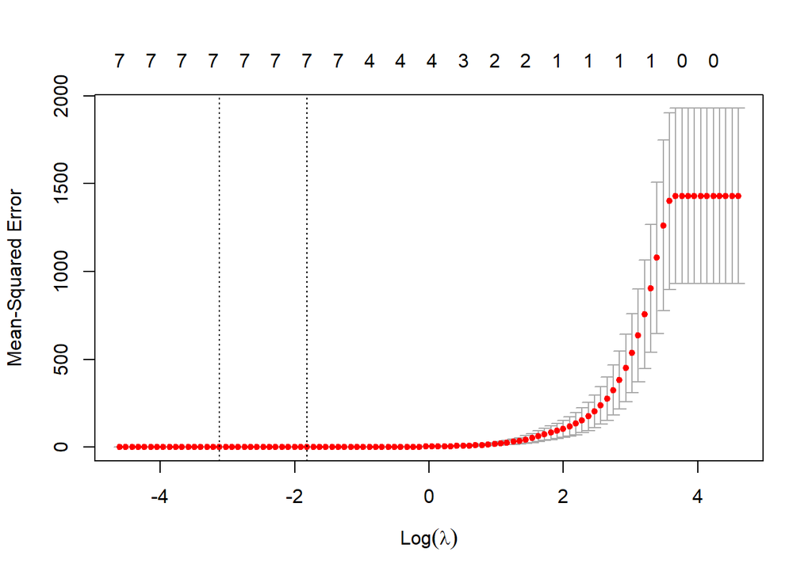

```r
grid <- 10^seq(-2, 2, length = 100)
data <- as.matrix(data)
result_lasso <- cv.glmnet(data[, -11], data[, 11], alpha = 1, lambda = grid)
plot(result_lasso)
```

```r
lambda_min <- result_lasso$lambda.min
lasso_coef <- predict(result_lasso, type = "coefficients", s = lambda_min)[1:10, ]
lasso_coef[lasso_coef != 0]
```

```
##  (Intercept)           X1           X2           X3           X4           X5
## 9.166967e+00 2.105351e+00 4.630698e+00 1.287073e+01 4.631948e-02 3.202283e-03
##           X7           X9
## 3.046017e-03 1.840577e-04
```

lasso回归剔除了$X^6$、$X^8$和$X^{10}$三项。

```r
lasso_coef[lasso_coef > 0.05]
```

```
## (Intercept)          X1          X2          X3
##    9.166967    2.105351    4.630698   12.870734
```

不考虑变量系数远小于1的情况，lasso回归最终选择了$X$、$X^2$和$X^3$三项，与前述几种模型基本一致，且与原模型比较接近。

```r
names(result_lasso)
```

```
##  [1] "lambda"     "cvm"        "cvsd"       "cvup"       "cvlo"
##  [6] "nzero"      "call"       "name"       "glmnet.fit" "lambda.min"
## [11] "lambda.1se"
```

（f）现在依据模型$Y = \beta_0 + \beta_7X^7 + \varepsilon$产生响应变量$Y$，使用最优子集选择法和lasso

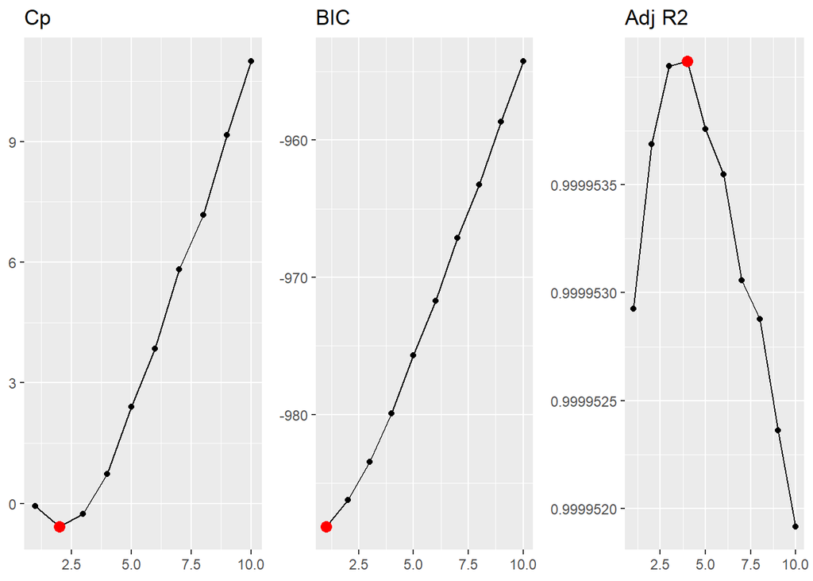

```r
y <- 9 + 2.3 * x^7 + noise
data <- data.frame(poly(x, 10, raw = T), y)

# 最优子集选择法
result_sub <- regsubsets(y ~ ., data = data, nvmax = 10)
plotf(result_sub)
```

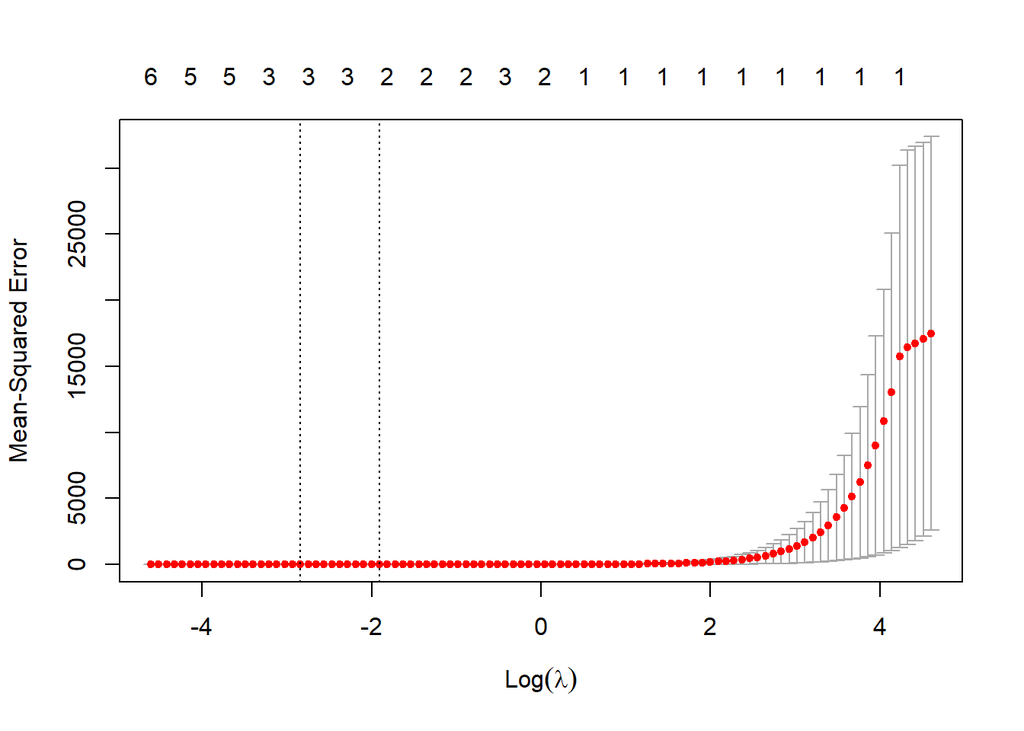

```r
# lasso
data <- as.matrix(data)
result_lasso <- cv.glmnet(data[, -11], data[, 11], alpha = 1, lambda = grid)
plot(result_lasso)
```

```r
# 最优子集选择法系数
coef <- lapply(c(1,2,4), function(x) coef(result_sub, x))

# lasso回归系数
lasso_min <- result_lasso$lambda.min
coef_lasso <- predict(result_lasso, type = "coefficients", s = lasso_min)[1:10,]
coef <- c(coef, list(coef_lasso[coef_lasso > 0.5]))

names(coef) <- c(paste("Best Subset Selection", 1:3), "Lasso")
```

```r
coef
```

```
## $`Best Subset Selection 1`
## (Intercept)          X7
##     8.95894     2.30077
##
## $`Best Subset Selection 2`
## (Intercept)          X2          X7
##   9.0704904  -0.1417084   2.3015552
##
## $`Best Subset Selection 3`
## (Intercept)          X1          X2          X3          X7
##   9.0762524   0.2914016  -0.1617671  -0.2526527   2.3091338
##
## $Lasso
## (Intercept)          X7
##    9.023038    2.295236
```

### 第五周任务：P182 第9题 预测申请人数

```r
library(ISLR)
library(glmnet)
library(pls)
data = College
data$Private <- as.numeric(data$Private) - 1
```

（a）把数据集分割为训练集和测试集

```r
set.seed(1)
index <- sample(1:nrow(data), nrow(data)*0.7)

trainData <- data[index, ]
testData <- data[-index, ]
```

（b）拟合最小二乘模型，计算测试误差

```r
model_ols <- lm(Apps ~., data = trainData)
predict_ols <- predict(model_ols, newdata = testData)
mse_ols <- mean((testData$Apps - predict_ols)^2)

mse_ols
```

```
## [1] 1261630
```

（c）拟合岭回归模型，使用交叉验证选择参数$\lambda$的值，计算测试误差

```r
trainMatrix <- as.matrix(trainData)
testMatrix <- as.matrix(testData)

set.seed(1)
model_ridge <- cv.glmnet(trainMatrix[, -2], trainMatrix[, 2], alpha = 0)
lambda <- model_ridge$lambda.min
predict_ridge <- predict(model_ridge, newx = testMatrix[, -2], s = lambda)
mse_ridge <- mean((testData$Apps - predict_ridge)^2)

cat("Ridge Regression", "\n MSE value: ", mse_ridge)
```

```
## Ridge Regression
##  MSE value:  1121034
```

（d）拟合lasso模型，使用交叉验证选择参数$\lambda$的值，计算测试误差和非零系数估计值的个数

```r
set.seed(1)
model_lasso <- cv.glmnet(trainMatrix[, -2], trainMatrix[, 2], alpha = 1)
lambda <- model_lasso$lambda.min
predict_lasso <- predict(model_lasso, newx = testMatrix[, -2], s = lambda)
coef_lasso <- predict(model_lasso, s = lambda, type = "coefficients")[, 1]
coef_lasso <- coef_lasso[coef_lasso != 0]
mse_lasso <- mean((testData$Apps - predict_lasso)^2)


cat("Lasso Model", "\n MSE value: ", mse_lasso,
    "\n num of coef: ", length(coef_lasso))
```

```
## Lasso Model
##  MSE value:  1233246
##  num of coef:  15
```

（e）拟合PCR模型，使用交叉验证选择参数M的值，计算测试误差和交叉验证选择的M

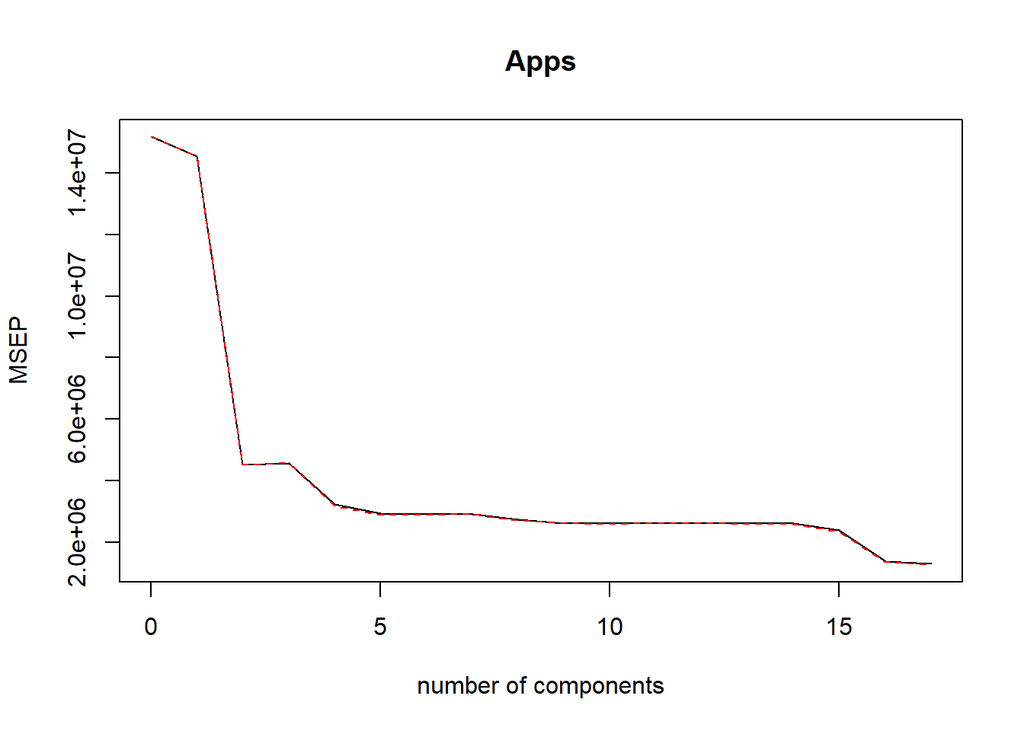

```r
set.seed(1)
model_pcr <- pcr(Apps ~., data = trainData, scale = T, validation = "CV")
validationplot(model_pcr, val.type = "MSEP")
```

```r
predict_pcr <- predict(model_pcr, testData, ncomp = 16)
mse_pcr <- mean((testData$Apps - predict_pcr)^2)

cat("PCR", "\n M: ", 16,
    "\n MSE value: ", mse_pcr)
```

```
## PCR
##  M:  16
##  MSE value:  1332330
```

（f）拟合PLS模型，使用交叉验证选择参数M的值，计算测试误差和交叉验证选择的M

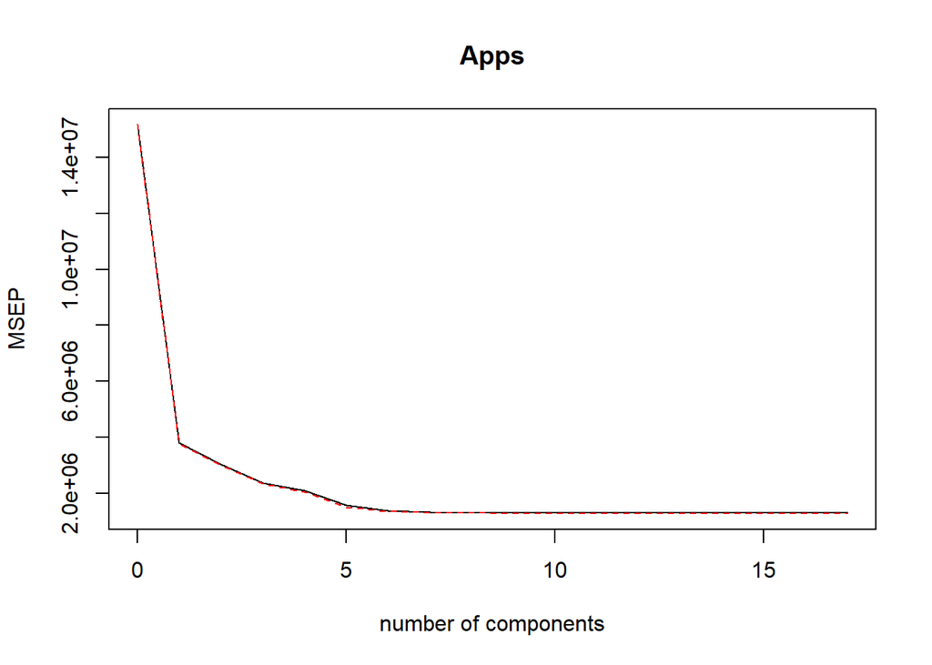

```r
set.seed(1)
model_pls <- plsr(Apps ~., data = trainData, scale = T, validation = "CV")
validationplot(model_pls, val.type = "MSEP")
```

```r
predict_pls <- predict(model_pls, testData, ncomp = 11 )
mse_pls <- mean((testData$Apps - predict_pls)^2)

cat("PCR", "\n M: ", 11,
    "\n MSE value: ", mse_pls)
```

```
## PCR
##  M:  11
##  MSE value:  1256121
```

（g）

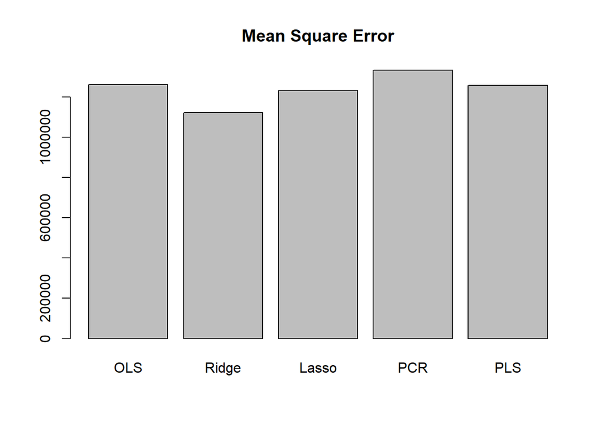

```r
# 合并MSE结果
mse <- c(mse_ols, mse_ridge, mse_lasso, mse_pcr, mse_pls)
names(mse) <- c("OLS", "Ridge", "Lasso", "PCR", "PLS")
barplot(mse, main = "Mean Square Error")
```

```r
# 计算R方
r2fun <- function(predicts) {
    y <- testData$Apps
    return  (1 - mean((y - predicts)^2) / mean((y - mean(y))^2))
}

R_2 <- c(r2fun(predict_ols), r2fun(predict_ridge), r2fun(predict_lasso),
         r2fun(predict_pcr), r2fun(predict_pls))
names(R_2) <- c("OLS", "Ridge", "Lasso", "PCR", "PLS")

cat("\n R Square: \n", R_2,
    "\n\n MSE: \n", mse)
```

```
##
##  R Square:
##  0.9134458 0.9230914 0.9153931 0.9085954 0.9138238
##
##  MSE:
##  1261630 1121034 1233246 1332330 1256121
```

各个模型的R方都达到了90%以上，说明对申请人数的预测情况较好；从测试集的均方误差来看，模型之间的差别并不太大，其中PCR/PLS作为能够优化OLS的降维方法，其泛化误差并没有得到明显的降低，而采用增加正则化惩罚项的两个模型的优化效果比较明显，尤其是岭回归。